# Your Digest for Thursday, Sep 14, 2023 11:59 PM

Conn syndrome was named after J. W. Conn who first described it in 1955, in a patient who had hypertension with an **aldosterone-producing adenoma**.

> [!INFO] Features of Conn's syndrome:
> - Elevated Na
> - Hypokalemia
> - Metabolic alkalosis
> - Impaired glucose tolerance (hypokalemia inhibits insulin secretion)
> - [Source](https://www.ncbi.nlm.nih.gov/books/NBK459197/)

- Graves *ophthalmolathy* [[#^4c27cc|See below]] is a prominent feature. Occurs because of **T cell infiltrations**;

> [!INFO] Definition of Graves ophthalmopathy:  
> **Ophthalmopathy** is characterized by inflammation of the extraocular muscles and orbital fat and connective tissue, which results in proptosis (**exophthalmos**), i**mpairment of eye muscle function**, and **periorbital edema**.

> > (In a child with thyrotoxicosis) the presence of eye findings such as **exophthalmos** or **ocular muscle dysfunction** essentially always points to Graves disease. "Stare" and lid lag are common in children with any form of hyperthyroidism and occur due to increased sympathetic tone.

> Volume of retro-orbital tissue is increased by 1) T cell infiltration, 2) Inflammatory oedema, 3) Increased extracellular matrix deposition, 4) increased adipocytes.  
> Graves dermopathy and ophthalmopathy may also be due to TRAb antibody reactivity with eye and skin tissue which may also express TSH receptor like protein. - UpToDate.

> [!INFO] Eye signs  
> Lid retraction: can be of the upper or lower eye lid. Definitions are varied and confusing.  
> Lid lag: Failure of the upper eye lid follow the globe as the gaze is moved donwards.  
> [Source](https://pubmed.ncbi.nlm.nih.gov/17900690/)  
> As above, lid retraction is more suggestive of Grave's ophthalmopathy.

#2021SBR-NOV Q13

## Patterns of elevation of jaundice

#2021SBR-NOV Q04

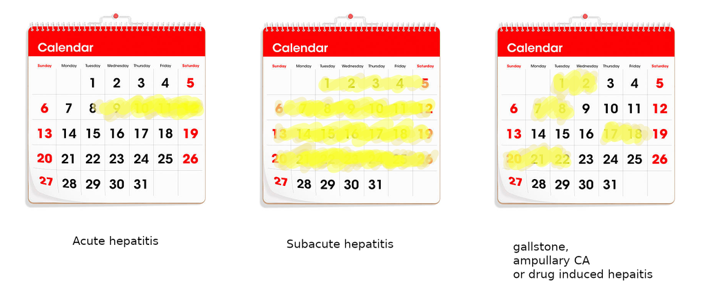

| Pattern | Causes |  |
| --- | --- | --- |
| Rise over few days to one day | Hepatitis of any cause |  |
| Jaundicer over weeks | Subacute hepatitis or extrahepatic obstruction |  |
| Fluctuating jaundice | gallstones, ampullary CA or drug hepatitis, primary sclerosing cholangitis | ? with repeated drug doses? |

[Source](https://www.ncbi.nlm.nih.gov/books/NBK413/)

## Definition of conjugated hyperbilirubinemia

#2021SBR-NOV

> [!INFO] Definition of direct / conjugated hyperbilirubinemia  
> Direct bilirubin > 2 mg/dL or more than **20%** of Total Serum Bilirubin.  
> [Source](https://www.ncbi.nlm.nih.gov/books/NBK562172/)

> [!TIP] Mnemonics:  
> Can't Neuter UNcooperative Goats

> [!INFO] Effect on C peptide  
> #2021SBR-NOV Q05  
> Since sulfonylureas stimulate the release of endogenous insulin, the plasma levels of insulin and C-peptide are inappropriately high in patients with sulfonylurea-induced hypoglycemia. These plasma levels are higher than those in patients with an insulinoma. [Source](https://www.medscape.com/viewarticle/432906_6)

### Diagnosis:

Diagnostic test is Hb electrophoresis: no HbA, **90-95% HbS and 2-20% HbF**.

### Management:

- Anaemia with *elevated Erythropoietin levels* occurs in old age. This is mild, normocytic and hypoproliferative (low retic count)

# Bell's palsy

#2021BSQ-NOV Q36

# Renal tubular acidosis

#2021SBR-NOV Q01

> [!INFO] RTA causes a 'hyperchloremic, normal anion gap, metabolic acidosis'.  
> [YouTube](https://www.youtube.com/watch?v=-1sD1hFENHs&t=505s) - "Renal tubular acidosis causes a *hyperchloremic, normal anion gap, metabolic acidosis*"

> [!INFO] "Two One Four - Low Low More"  
> Order of Columns : K-CaPStone

[figure not shown]

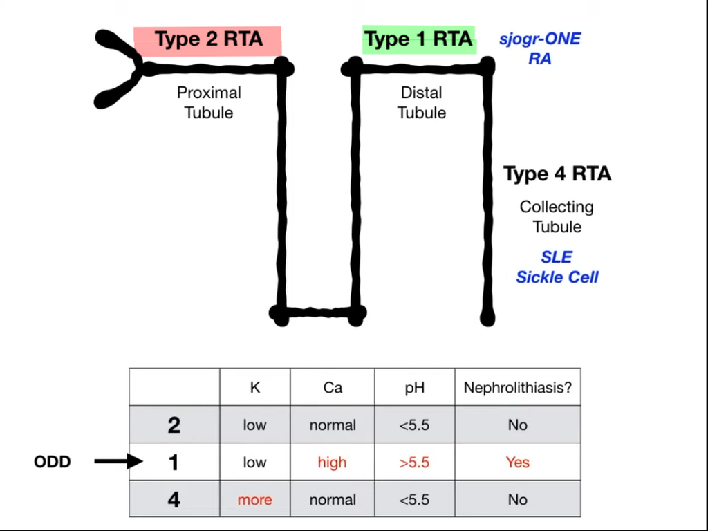

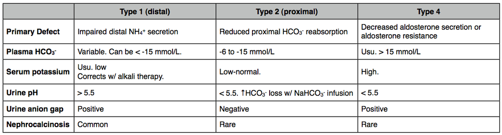

> | Nomenclature | - |
> | --- | --- |
> | Type 1 RTA | Distal RTA |
> | Type 2 RTA | Proximal RTA |
> | Type 4 RTA | Hyperkalaemic RTA |

# Autoimmune hepatitis

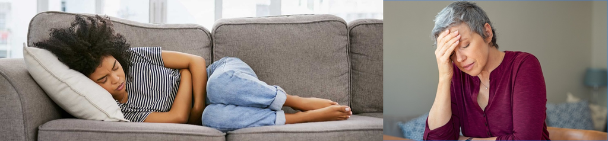

75% **female** predominance.  
Strongly associated with either personal or family history of **autoimmune disease**.

- Perimenopausal ladies will present with mild fatigue and elevated liver enzymes.
- Girls in teens and early twenties will present with acute hepatitis with very high liver enzymes.

**1/3 of patients have cirrhocis at presentation!**.

**Treatment:** Initiated with steroid and azathioprine. Lifelong treatment usually required.  
The good news is that 80% go into remission with treatment. FC

Other features of autoimmune disease may be present in the young group:

- Fever,
- Migratory polyarthritis
- Glomerulonpheritis
- Pulmonary infiltration or lung fibrosis

Investigations: AST, ALT high. ALP moderately high. High gamma globulins, elevated PT.  
**Biopsy** is mandatory to confirm the dianosis; It will show **interface hepatitis and chronic active hepatitis**.  
Type I AIH has **ANA** and **anti-smooth muscle antibodies**.  
Type II - **anti liver kidney microsomal antibodies**. LKM1

# C peptide

> The 2 major indications for measuring C-peptide levels include fasting hypoglycemia and assessment of insulin secretory reserve in patients with diabetes.
- C peptide half life is about 30 minutes. [Source](https://www.ncbi.nlm.nih.gov/books/NBK526026/)
- C-peptide is secreted in equimolar concentrations with insulin from the beta cells.
- It is a valid measure of insulin secretion especially following challenges with glucagon or a mixed meal.
- C-peptide is extremely useful in the differential diagnosis of hyperinsulinemic-hypoglycemia.
- [[General medicine 5#Sulfonylureas|C peptide level is increased by sulfonylureas]]

# Coeliac disease

Gluten sensitive enteropathy (GSE)  
One of the diseases causing intestinal malabsorption

> [!TIP] Diseases causing intestinal malabsorption  
> **Cats dance better than iguanas wearing red pants**

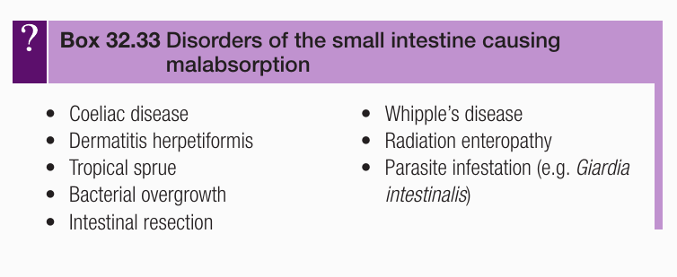

## Pathogenesis

- **Gluten** is the protein content found in cereals.
- Prolamins are proteins which have high glutamine and proline content so they don't get digested by pepsin and pass into the intestine.
- Prolamins actually *pass through the epithelium* and undergo deamination by *transglutaminase* which makes them more immunogenic.
- CD4 T cells are stimulated and the resulting inflammation causes disease.
- Interferon gamma is involved.
- The disease process results in crypt hyperplasia and villous atrophy.

> [!WARNING] Medical emergency!

*?Hallucinations are usually visual in Delerium tremens.*

Symptoms worse at night. Settles in 3 - 4 days and patient goes into a deep prolonged sleep and wakes up refreshed.  
#2021GM-NOV Q31

[output not shown]

- Progressive and chronic liver disease caused by autoimmune mediated fibrosis of intra and extrahepatic bile ducts.
- Strongly associated with IBD (mainly **ulcerative colitis**)
- Associated with **pANCA** positivity.
- Often complicated by **recurrent cholangitis** and **cholangiocarcinoma**.
- Treament is not curative; it's aimed at minimizing symptoms and managing complications.
- **Liver transplantation** is the only treatment than can alter progression. Drugs won't work.
- Affects young to middle aged **males** (in their 40s)
  - PSC without IBD is more likely to occur in women.
  - PSC is seen predominantly in **non smokers**.
  - (Remember that smoking protects against ulcerative colitis! so if you smoke, you have less risk of UC and associated PSC)
- Ix: AST, ALT, GGT all elevated. **Fluctuating** conjugated hyperbilirubinaemia.
- **hypergammaglobulinaemia** is present.
- Best imaging modality: MRCP
- **ultimately leads to** cirrhocis.

# Primary Biliary Cirrhocis / Primary Biliary Cholangitis

> [!TIP] PBC - the C can stant for Cirrhocis or Cholangitis.

> [!TIP] When to suspect  
> Suspect in a middle aged woman with pruritus who has elevated ALP and possible other autoimmune conditions.

> MCQ Discussion:  
> Most often diagnosed through routine screening. **Usually asymptomatic.**  
> But Fatigue is a prominent presenting symptom. Icterus and pruritus are late signs.
- 95% of PBC occurs in women aged 40 - 50 years.
- There is destruction of small **interlobular** *bile ducts*.
- Antimitochondrial antibodies are found in all patients. M2 is specific for PBC.
- Presentation: Asymptomatic with #hepatomegaly and raised **ALP**. (raised ALP is often the only abnormal investigation)
- Pruritus and fatigue.
- Raised cholesterol and Xanthelasma
- Associated with many autoimmune conditions.
- Histology: portal tract infiltrate with hepatic granulomas; changes start in zone 1.

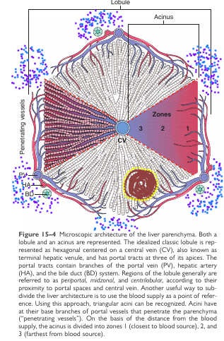

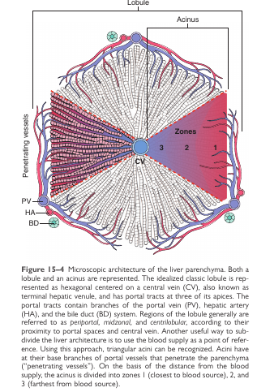

[output not shown]

Binds GABA-A receptor, potentiates GABA action, causing hyper polarization and increased neuronal stability.